# Import a Keras model into IBM Watson Machine Learning

Importing a model into Watson Machine Learning means to store a trained model in your Watson Machine Learning repository and then deploy the stored model. This notebook demonstrates importing a Keras model.

See also: [Importing a Keras model](https://dataplatform.cloud.ibm.com/docs/content/analyze-data/ml-import-keras.html)

This notebook runs on Python 3.6 and uses `keras 2.2.4`.

### Notebook sections

Step 1: Build, train, and save a model

Step 2: Store the model in your Watson Machine Learning repository

Step 3: Deploy the stored model in your Watson Machine Learning service

## Step 1: Build, train, and save a model

**About the sample model**

The sample model built here classifies text messages from fictional customers into two categories:

- "social" : The message might just be social and friendly, or the message lacks enough text to perform in-depth analysis
- "problem or question" : The message describes a problem or asks a question

Classifying messages this way is useful for multiple purposes:

- Automating responses (eg. respond to social messages with a generial greeting, prompting the user to type their question or problem if they have one)
- Cleaning out social message for post-hoc analysis

The data used to train the model is the "sample-customer-messages.csv" training data in the IBM Watson Studio community: [Customer messages sample data](https://dataplatform.cloud.ibm.com/exchange/public/entry/view/015ddef6a868441188268a123404f744).

### Load and prepare training data

1. Go to the [Customer messages](https://dataplatform.cloud.ibm.com/exchange/public/entry/view/015ddef6a868441188268a123404f744) data set in the Watson Studio Gallery.
2. Load the .csv file as a Data Asset in your project by clicking the **Add to Project** button in the upper-right corner of the page. Select your project name and click **Add**. You can now view the data set in your project.
3. Load the Customer messages .csv file into your notebook. Click the Data icon on the notebook action bar. Scroll through your list of assets to find the Customer messages .csv that you added to your project earlier. **Note:** If you can't find the data asset, reload your notebook. To load the data into a DataFrame, click in the next code cell and select **Insert to code > Insert Pandas DataFrame** under the file name.
4. Change `df_data_x = pd.read_csv(body)` to `df = pd.read_csv(body, names=["message", "class_name"])`.
5. Also, change `df_data_1.head()` to `df.head()`.
6. Run the cell.

```python
import types
import pandas as pd
from botocore.client import Config
import ibm_boto3

def __iter__(self): return 0

# @hidden_cell
# The following code accesses a file in your IBM Cloud Object Storage. It includes your credentials.
# You might want to remove those credentials before you share the notebook.
```

|  | message | class_name |
| --- | --- | --- |
| 0 | excuse me | hi |
| 1 | Good evening | hi |
| 2 | Good morning | hi |
| 3 | good morning | hi |
| 4 | Good morning can you help me upload a shapefile? | question |

```python
# # Read sample data into Pandas DataFrame
df[6:9]
```

|  | message | class_name |
| --- | --- | --- |
| 6 | Greetings :) | hi |
| 7 | hai how can i do analyze with csv file is ther... | question |
| 8 | Having issues setup WML service | problem |

```python
# Split the data into training and test sets
# https://scikit-learn.org/stable/modules/generated/sklearn.model_selection.train_test_split.html
from sklearn.model_selection import train_test_split
train, test = train_test_split( df, test_size = 0.1 )
test
```

|  | message | class_name |
| --- | --- | --- |
| 67 | Hi not able to signup | problem |
| 6 | Greetings :) | hi |
| 86 | I cant see my spark instance when i go to cre... | problem |
| 0 | excuse me | hi |
| 36 | hi | hi |
| 27 | Hello! please can you help | hi |
| 24 | hello message keeps coming which says my servi... | problem |
| 87 | I deployed my WatsonML model and have a Scorin... | problem |
| 78 | how do i save my data as a csv file | question |
| 11 | Hello | hi |

```python
!pip install --upgrade keras==2.2.4
```

```python
# Convert words to numbers
# https://keras.io/preprocessing/text/#tokenizer
from keras.preprocessing.text import Tokenizer
t = Tokenizer()
t.fit_on_texts( train["message"] )
X_train = t.texts_to_sequences( train["message"] )
X_test  = t.texts_to_sequences( test["message"] )
X_test[0:4]
```

```
[[3, 58, 117, 1, 185], [], [2, 124, 8, 266, 25, 2, 1, 16, 4, 53, 29], [24]]
```

```python
# Pad the shorter entries
# https://keras.io/preprocessing/sequence/#pad_sequences
from keras.preprocessing.sequence import pad_sequences
max_len = max( len(x) for x in X_train )
X_train = pad_sequences( X_train, padding='post', maxlen=max_len )
X_test  = pad_sequences( X_test,  padding='post', maxlen=max_len )
X_test[0]
```

```
array([  3,  58, 117,   1, 185,   0,   0,   0,   0,   0,   0,   0,   0,
         0,   0,   0,   0,   0,   0,   0,   0,   0,   0,   0,   0,   0,
         0,   0,   0], dtype=int32)
```

```python
# Convert the labels to binary labels
import scipy
import numpy as np
y_train = np.array( [ [ 1, 0 ] if class_name == "hi" else [ 0, 1 ] for class_name in train[ "class_name" ] ] )
y_test  = np.array( [ [ 1, 0 ] if class_name == "hi" else [ 0, 1 ] for class_name in test[ "class_name" ] ] )
y_test
```

```
array([[0, 1],
       [1, 0],
       [0, 1],
       [1, 0],
       [1, 0],
       [1, 0],
       [0, 1],
       [0, 1],
       [0, 1],
       [1, 0]])
```

### Build a neural network

```python
# Create a simple sequential model
# https://keras.io/models/sequential

from keras.models import Sequential
from keras import layers
import tensorflow as tf
tf.logging.set_verbosity(tf.logging.ERROR)


vocab_size    = len( t.word_counts ) + 1
embedding_dim = 50
num_classes   = 2

model = Sequential()
model.add( layers.Embedding( input_dim    = vocab_size,        # https://keras.io/layers/embeddings
                             output_dim   = embedding_dim,
                             input_length = max_len,
                             trainable    = True ) )
model.add( layers.Flatten() )                                  # https://keras.io/layers/core/#flatten
model.add( layers.Dense( num_classes, activation='sigmoid' ) ) # https://keras.io/layers/core/#dense
model.add( layers.Activation( "softmax" ) )                    # https://en.wikipedia.org/wiki/Softmax_function

model.compile( optimizer = "adam",                # https://www.dlology.com/blog/quick-notes-on-how-to-choose-optimizer-in-keras
               loss      = "binary_crossentropy", # https://www.dlology.com/blog/how-to-choose-last-layer-activation-and-loss-function
               metrics   = [ "accuracy" ] )
```

### Train and evaluate model

```python
num_epochs = 15

history = model.fit( X_train, y_train,
                     batch_size = 10,
                     epochs     = num_epochs,
                     verbose    = False,
                     validation_split = 0.1 )
```

```python
import matplotlib.pyplot as plt
```

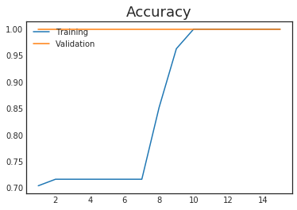

```python
plt.style.use( "seaborn-white" )

plt.title(  "Accuracy", fontsize = 18)

x = range( 1, num_epochs + 1 )
plt.plot( x, history.history[ "acc" ],     label = "Training"   )
plt.plot( x, history.history[ "val_acc" ], label = "Validation" )

legend = plt.legend( loc="upper left" )
plt.show()
```

```python
test
```

|  | message | class_name |
| --- | --- | --- |
| 67 | Hi not able to signup | problem |
| 6 | Greetings :) | hi |
| 86 | I cant see my spark instance when i go to cre... | problem |
| 0 | excuse me | hi |
| 36 | hi | hi |
| 27 | Hello! please can you help | hi |
| 24 | hello message keeps coming which says my servi... | problem |
| 87 | I deployed my WatsonML model and have a Scorin... | problem |
| 78 | how do i save my data as a csv file | question |
| 11 | Hello | hi |

```python
test_results = model.predict_classes( X_test )
print( test_results )
```

```
[0 0 1 0 0 0 1 1 1 0]
```

### Save the model in a .tgz file

```python
# https://keras.io/getting-started/faq/#how-can-i-save-a-keras-model
model.save( "message-classification-model.h5" )
```

```python
!tar -zcvf message-classification-model.tgz message-classification-model.h5
```

```
message-classification-model.h5
```

```python
!ls -l
```

```
total 34876
-rw-r----- 1 dsxuser dsxuser   229128 Nov  4 22:43 message-classification-model.h5
-rw-r----- 1 dsxuser dsxuser   186865 Nov  4 22:43 message-classification-model.tgz
-rw-r----- 1 dsxuser dsxuser   475816 Nov  4 22:25 mnist-html-canvas-image-data.json
-rw-r----- 1 dsxuser dsxuser 34803755 Nov  4 22:25 mnist-tf-hpo-saved-model.tar.gz
drwxr-x--- 2 dsxuser dsxuser     4096 Nov  4 22:12 STYLE_DATA
-rw-r----- 1 dsxuser dsxuser     3954 Nov  4 22:12 STYLE.zip
```

## Step 2: Store the model in your Watson Machine Learning repository

This section of the notebook demonstrates calling the store_model function

Paste your Watson Machine Learning credentials in the following cell.

See: [Looking up credentials](https://dataplatform.cloud.ibm.com/docs/content/analyze-data/ml-get-wml-credentials.html)

```python
from watson_machine_learning_client import WatsonMachineLearningAPIClient
```

```python
# Create a Watson Machine Learning client instance
wml_credentials = {
    "apikey"     : "",
    "instance_id": "",
    "password"   : "",
    "url"        : "",
    "username"   : ""
}
```

```python
metadata = {
    client.repository.ModelMetaNames.NAME: "keras model",
    client.repository.ModelMetaNames.FRAMEWORK_NAME: "tensorflow",
    client.repository.ModelMetaNames.FRAMEWORK_VERSION: "1.14",
    client.repository.ModelMetaNames.FRAMEWORK_LIBRARIES: [{"name": "keras", "version": "2.2.4"}]
}
model_details = client.repository.store_model( model="message-classification-model.tgz", meta_props=metadata )
```

## Step 3: Deploy the stored the model in your Watson Machine Learning service

This section of the notebook demonstrates calling the [deployments.create](https://wml-api-pyclient.mybluemix.net/index.html?highlight=deploy#client.Deployments.create) function

```python
# Deploy the stored model as an online web service deployment
model_id = model_details["metadata"]["guid"]
deployment_details = client.deployments.create( artifact_uid=model_id, name="Keras deployment" )
```

```
#######################################################################################

Synchronous deployment creation for uid: '9b5baba9-7dbf-435b-8030-8a50749c7cd6' started

#######################################################################################


INITIALIZING
DEPLOY_IN_PROGRESS..
DEPLOY_SUCCESS


------------------------------------------------------------------------------------------------
Successfully finished deployment creation, deployment_uid='83947fef-c803-4ed0-999d-d521490b75bd'
------------------------------------------------------------------------------------------------
```

```python
# Get the deployment UID
deployment_uid = client.deployments.get_uid(deployment_details)
print("Deployment UID: {}".format(deployment_uid))
```

```
Deployment UID: 83947fef-c803-4ed0-999d-d521490b75bd
```

```python
# Test the deployment
model_endpoint_url = client.deployments.get_scoring_url( deployment_details )
payload = { "values" : X_test.tolist() }
client.deployments.score( model_endpoint_url, payload )
```

```
{'fields': ['prediction', 'prediction_classes', 'probability'],
 'values': [[[0.5121044516563416, 0.48789557814598083],
   0,
   [0.5121044516563416, 0.48789557814598083]],
  [[0.7076183557510376, 0.2923817038536072],
   0,
   [0.7076183557510376, 0.2923817038536072]],
  [[0.2785996198654175, 0.7214003801345825],
   1,
   [0.2785996198654175, 0.7214003801345825]],
  [[0.7072234153747559, 0.29277658462524414],
   0,
   [0.7072234153747559, 0.29277658462524414]],
  [[0.7055739164352417, 0.2944260537624359],
   0,
   [0.7055739164352417, 0.2944260537624359]],
  [[0.5287381410598755, 0.4712618291378021],
   0,
   [0.5287381410598755, 0.4712618291378021]],
  [[0.3014186918735504, 0.698581337928772],
   1,
   [0.3014186918735504, 0.698581337928772]],
  [[0.31170526146888733, 0.6882948279380798],
   1,
   [0.31170526146888733, 0.6882948279380798]],
  [[0.2955194115638733, 0.7044806480407715],
   1,
   [0.2955194115638733, 0.7044806480407715]],
  [[0.7071711421012878, 0.2928289473056793],
   0,
   [0.7071711421012878, 0.2928289473056793]]]}
```

## Summary

In this notebook, you imported a Keras model into Watson Machine Learning using the Watson Machine Learning Python client.

### Authors

**Sarah Packowski** is a member of the IBM Watson Studio Content Design team in Canada.

Copyright © IBM Corp. 2019. This notebook and its source code are released under the terms of the MIT License.

Love this notebook? Don't have an account yet?  
Share it with your colleagues and help them discover the power of Watson Studio! [Sign Up](https://ibm.co/wsnotebooks)